# PD5

Michał Tałałaj

2025-05-08

# Wstęp i opis eksperymentu

Wykresy typu spider chart są często krytykowane przez ekspertów w dziedzinie wizualizacji danych z wielu względów. Ciężko z nich szybko odczytać dokładne wartości, zwłaszcza gdy porównujemy wiele obiektów jednocześnie. Linie i obszary mogą się na siebie nakładać, tworząc wizualny chaos, który utrudnia interpretację. Dodatkowo, ludzie mają naturalne trudności z porównywaniem długości promieni rozchodzących się od wspólnego środka w różnych kierunkach — znacznie trudniej to ocenić niż przykładowo długość słupków. Mimo to spider charty pozostają popularne, szczególnie w grach komputerowych, gdzie prezentują statystyki postaci w estetycznej formie.

# Przykłady

[figure not shown]

Statystyki gracza w League of Legends

[figure not shown]

Statystyki pokémona w Pokémon Let’s Go Pikachu

# Cel

Eksperyment będzie polegał na sprawdzeniu, którą formę prezentacji danych preferują osoby niezajmujące się na co dzień wizualizacją informacji. Uczestnicy badania zostaną poproszeni o ocenę wykresów przedstawiających te same dane w dwóch różnych formach: wykresie spider chart oraz w bardziej klasycznej i czytelnej formie, takiej jak wykres typu lollipop. Celem eksperymentu będzie ustalenie, czy estetyka i przyzwyczajenia wizualne przeważają nad klarownością przekazu, czy też użytkownicy intuicyjnie wybierają formy bardziej zgodne z zasadami efektywnej wizualizacji danych. Wyniki pozwolą ocenić, czy dawne dobre praktyki projektowania wykresów pozostają skuteczne w odbiorze współczesnych użytkowników.

# Porównanie dwóch statystyk na jednym wykresie

Wykresy na podstawie danych na temat pokémonów (z labów)

[figure not shown]

[figure not shown]

# Wnioski 1

W przypadku porównywania dwóch wartości na jednym wykresie zdania ankietowanych są podzielone. Wśród badanych 56% osób uznała, że porównywanie danych na wykrescie radarowym pozwala im na szybsze zobczenie, który z pokémonów przewyższa drugiego w danej statystyce, ale tylko 18% uznało, że może z niego dokładniej oszacować poszczególne różnice. Zdecydowana większość ankietowanych - aż 68% stwierdziła, że wykres radarowy w tym przypadku jest bardziej estetyczny. Ponad połowa - 56% uważa, że sposób przedstawienia danych w wykresie radarowym utrudniła im ocene różnic między Pokémonami. Paradoksalnie tyle samo osób uznało ten wykres za bardziej profesjonalny.

# Przedstawienie statystyk jednego pokémona

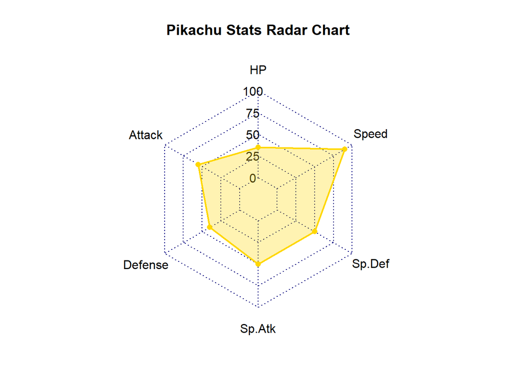

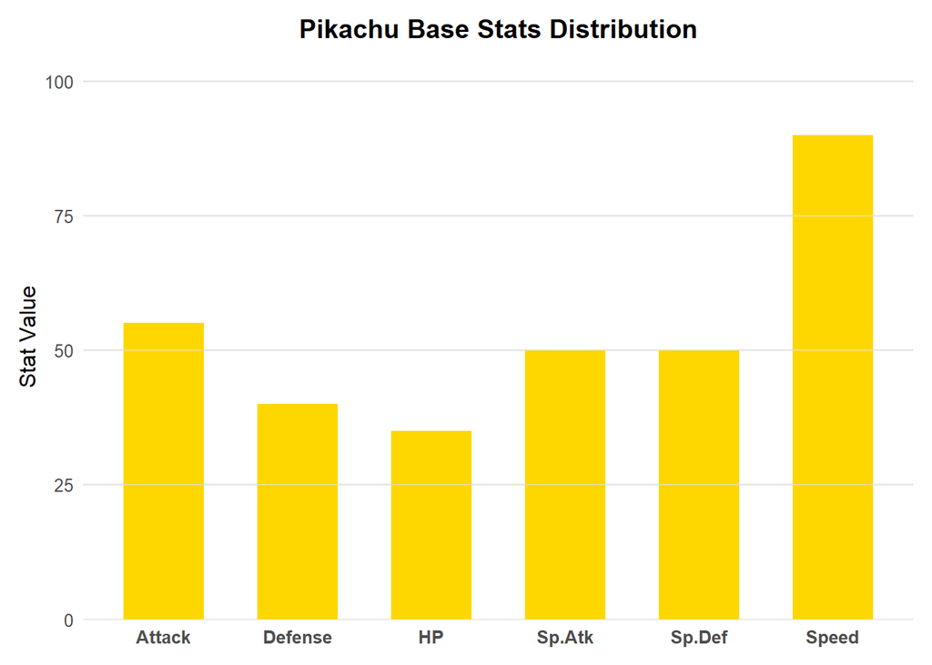

# Wnioski 2

W przypadku odczytywania jednej wartości ankietowani zdecydowanie preferują wykres słupkowy. W każdym pytaniu dotyczącym czytelności 93% odpowiedzi preferowało wykresy słupkowe. Zaledwie 25% osób uznało wykres słupkowy za mniej profesjonalny za jego minimalistyczną formę.

# Podsumowanie

Wyniki badania potwierdzają postawioną tezę – choć wykresy typu spider chart wyglądają efektownie i cieszą się popularnością, to nie sprawdzają się najlepiej tam, gdzie liczy się dokładność i czytelność danych. Ich forma, choć estetyczna, często utrudnia szybkie porównywanie wartości i może wprowadzać zamieszanie. Tradycyjniejsze formy wizualizacji, takie jak wykresy słupkowe, okazują się zna bardziej przejrzyste i intuicyjne, szczególnie gdy celem jest jasne pokazanie różnic między wartościami. Pokazuje to, że atrakcyjna forma graficzna nie zawsze idzie w parze z funkcjonalnością, a przy projektowaniu wykresów warto kierować się nie tylko wyglądem, ale przede wszystkim łatwością odbioru informacji.

Link do ankiety: https://forms.gle/myRvAQfqenNfMnnV8